# HW 4

This assignment covers Linear Classification methods

**DO NOT ERASE MARKDOWN CELLS AND INSTRUCTIONS IN YOUR HW submission**

- **Q** - QUESTION
- **A** - Where to input your answer

## Instructions

Keep the following in mind for all notebooks you develop:

- Structure your notebook.
- Use headings with meaningful levels in Markdown cells, and explain the questions each piece of code is to answer or the reason it is there.
- Make sure your notebook can always be rerun from top to bottom.
- Please start working on this assignment as soon as possible. If you are a beginner in Python this might take a long time. One of the objectives of this assignment is to help you learn python and scikit-learn package.
- See README.md for homework submission instructions

## Related Tutorials

### Refreshers

- [Intro to Machine Learning w scikit-learn](https://scikit-learn.org/stable/tutorial/basic/tutorial.html)
- [A tutorial on statistical-learning for scientific data processing](https://scikit-learn.org/stable/tutorial/statistical_inference/index.html#stat-learn-tut-index)

### Classification Approaches

- [Logistic Regression with Sklearn](https://scikit-learn.org/stable/modules/generated/sklearn.linear_model.LogisticRegression.html)
- [KNN with sklearn](https://scikit-learn.org/stable/modules/generated/sklearn.neighbors.KNeighborsClassifier.html)

### Modeling

- [Cross-validation](https://scikit-learn.org/stable/modules/cross_validation.html)
- [Plot Confursion Matrix with Sklearn](https://scikit-learn.org/stable/auto_examples/model_selection/plot_confusion_matrix.html)
- [Confusion Matrix Display](https://scikit-learn.org/stable/modules/generated/sklearn.metrics.ConfusionMatrixDisplay.html#sklearn.metrics)

# Data Processing

**Q1** Get training data from the dataframe

1. Load mobile_data.csv from ```data'' folder into the dataframe
2. Assign values of `price_range` column to `y`
3. Drop 'price_range' column from data frame,
4. Assign remaining df column values to x
5. Print the head of the dataframe

**A1** Replace ??? with code in the code cell below

```python
import numpy as np
import pandas as pd
from sklearn.model_selection import train_test_split
from sklearn.linear_model import LogisticRegression
from matplotlib import pyplot as plt
from sklearn.preprocessing import StandardScaler

#Read the mobile_data.csv file using the prropriate separator as input to read_csv()
df = pd.read_csv('data/mobile_data.csv')

df.head()
```

|  | battery_power | blue | clock_speed | dual_sim | fc | four_g | int_memory | m_dep | mobile_wt | n_cores | ... | px_height | px_width | ram | sc_h | sc_w | talk_time | three_g | touch_screen | wifi | price_range |
| --- | --- | --- | --- | --- | --- | --- | --- | --- | --- | --- | --- | --- | --- | --- | --- | --- | --- | --- | --- | --- | --- |
| 0 | 842 | 0 | 2.2 | 0 | 1 | 0 | 7 | 0.6 | 188 | 2 | ... | 20 | 756 | 2549 | 9 | 7 | 19 | 0 | 0 | 1 | 1 |
| 1 | 1021 | 1 | 0.5 | 1 | 0 | 1 | 53 | 0.7 | 136 | 3 | ... | 905 | 1988 | 2631 | 17 | 3 | 7 | 1 | 1 | 0 | 2 |
| 2 | 563 | 1 | 0.5 | 1 | 2 | 1 | 41 | 0.9 | 145 | 5 | ... | 1263 | 1716 | 2603 | 11 | 2 | 9 | 1 | 1 | 0 | 2 |
| 3 | 615 | 1 | 2.5 | 0 | 0 | 0 | 10 | 0.8 | 131 | 6 | ... | 1216 | 1786 | 2769 | 16 | 8 | 11 | 1 | 0 | 0 | 2 |
| 4 | 1821 | 1 | 1.2 | 0 | 13 | 1 | 44 | 0.6 | 141 | 2 | ... | 1208 | 1212 | 1411 | 8 | 2 | 15 | 1 | 1 | 0 | 1 |

5 rows × 21 columns

```python
df.describe()
```

|  | battery_power | blue | clock_speed | dual_sim | fc | four_g | int_memory | m_dep | mobile_wt | n_cores | ... | px_height | px_width | ram | sc_h | sc_w | talk_time | three_g | touch_screen | wifi | price_range |
| --- | --- | --- | --- | --- | --- | --- | --- | --- | --- | --- | --- | --- | --- | --- | --- | --- | --- | --- | --- | --- | --- |
| count | 2000.000000 | 2000.0000 | 2000.000000 | 2000.000000 | 2000.000000 | 2000.000000 | 2000.000000 | 2000.000000 | 2000.000000 | 2000.000000 | ... | 2000.000000 | 2000.000000 | 2000.000000 | 2000.000000 | 2000.000000 | 2000.000000 | 2000.000000 | 2000.000000 | 2000.000000 | 2000.000000 |
| mean | 1238.518500 | 0.4950 | 1.522250 | 0.509500 | 4.309500 | 0.521500 | 32.046500 | 0.501750 | 140.249000 | 4.520500 | ... | 645.108000 | 1251.515500 | 2124.213000 | 12.306500 | 5.767000 | 11.011000 | 0.761500 | 0.503000 | 0.507000 | 1.500000 |
| std | 439.418206 | 0.5001 | 0.816004 | 0.500035 | 4.341444 | 0.499662 | 18.145715 | 0.288416 | 35.399655 | 2.287837 | ... | 443.780811 | 432.199447 | 1084.732044 | 4.213245 | 4.356398 | 5.463955 | 0.426273 | 0.500116 | 0.500076 | 1.118314 |
| min | 501.000000 | 0.0000 | 0.500000 | 0.000000 | 0.000000 | 0.000000 | 2.000000 | 0.100000 | 80.000000 | 1.000000 | ... | 0.000000 | 500.000000 | 256.000000 | 5.000000 | 0.000000 | 2.000000 | 0.000000 | 0.000000 | 0.000000 | 0.000000 |
| 25% | 851.750000 | 0.0000 | 0.700000 | 0.000000 | 1.000000 | 0.000000 | 16.000000 | 0.200000 | 109.000000 | 3.000000 | ... | 282.750000 | 874.750000 | 1207.500000 | 9.000000 | 2.000000 | 6.000000 | 1.000000 | 0.000000 | 0.000000 | 0.750000 |
| 50% | 1226.000000 | 0.0000 | 1.500000 | 1.000000 | 3.000000 | 1.000000 | 32.000000 | 0.500000 | 141.000000 | 4.000000 | ... | 564.000000 | 1247.000000 | 2146.500000 | 12.000000 | 5.000000 | 11.000000 | 1.000000 | 1.000000 | 1.000000 | 1.500000 |
| 75% | 1615.250000 | 1.0000 | 2.200000 | 1.000000 | 7.000000 | 1.000000 | 48.000000 | 0.800000 | 170.000000 | 7.000000 | ... | 947.250000 | 1633.000000 | 3064.500000 | 16.000000 | 9.000000 | 16.000000 | 1.000000 | 1.000000 | 1.000000 | 2.250000 |
| max | 1998.000000 | 1.0000 | 3.000000 | 1.000000 | 19.000000 | 1.000000 | 64.000000 | 1.000000 | 200.000000 | 8.000000 | ... | 1960.000000 | 1998.000000 | 3998.000000 | 19.000000 | 18.000000 | 20.000000 | 1.000000 | 1.000000 | 1.000000 | 3.000000 |

8 rows × 21 columns

```python
y = df['price_range']

# concerning part 3, I decided to combine it with part 4. I want to keep the original dataframe intact for later problems.
x = df.drop(columns=['price_range'])
```

```python
df.head()
```

|  | battery_power | blue | clock_speed | dual_sim | fc | four_g | int_memory | m_dep | mobile_wt | n_cores | ... | px_height | px_width | ram | sc_h | sc_w | talk_time | three_g | touch_screen | wifi | price_range |
| --- | --- | --- | --- | --- | --- | --- | --- | --- | --- | --- | --- | --- | --- | --- | --- | --- | --- | --- | --- | --- | --- |
| 0 | 842 | 0 | 2.2 | 0 | 1 | 0 | 7 | 0.6 | 188 | 2 | ... | 20 | 756 | 2549 | 9 | 7 | 19 | 0 | 0 | 1 | 1 |
| 1 | 1021 | 1 | 0.5 | 1 | 0 | 1 | 53 | 0.7 | 136 | 3 | ... | 905 | 1988 | 2631 | 17 | 3 | 7 | 1 | 1 | 0 | 2 |
| 2 | 563 | 1 | 0.5 | 1 | 2 | 1 | 41 | 0.9 | 145 | 5 | ... | 1263 | 1716 | 2603 | 11 | 2 | 9 | 1 | 1 | 0 | 2 |
| 3 | 615 | 1 | 2.5 | 0 | 0 | 0 | 10 | 0.8 | 131 | 6 | ... | 1216 | 1786 | 2769 | 16 | 8 | 11 | 1 | 0 | 0 | 2 |
| 4 | 1821 | 1 | 1.2 | 0 | 13 | 1 | 44 | 0.6 | 141 | 2 | ... | 1208 | 1212 | 1411 | 8 | 2 | 15 | 1 | 1 | 0 | 1 |

5 rows × 21 columns

**Q2:**

1. Check number of null values per column in the x dataframe.

**A2** Replace ??? with code in the code cell below

```python
# sum() will tally each column's empty cell. Value will be > 0 if there are empty cells in a column
x.isnull().sum()
```

```
battery_power    0
blue             0
clock_speed      0
dual_sim         0
fc               0
four_g           0
int_memory       0
m_dep            0
mobile_wt        0
n_cores          0
pc               0
px_height        0
px_width         0
ram              0
sc_h             0
sc_w             0
talk_time        0
three_g          0
touch_screen     0
wifi             0
dtype: int64
```

**Q3.1** Use seaborn heatmap chart to visualize the correlations between the columns. Replace ??? with code in the code cell below

**A3.1**

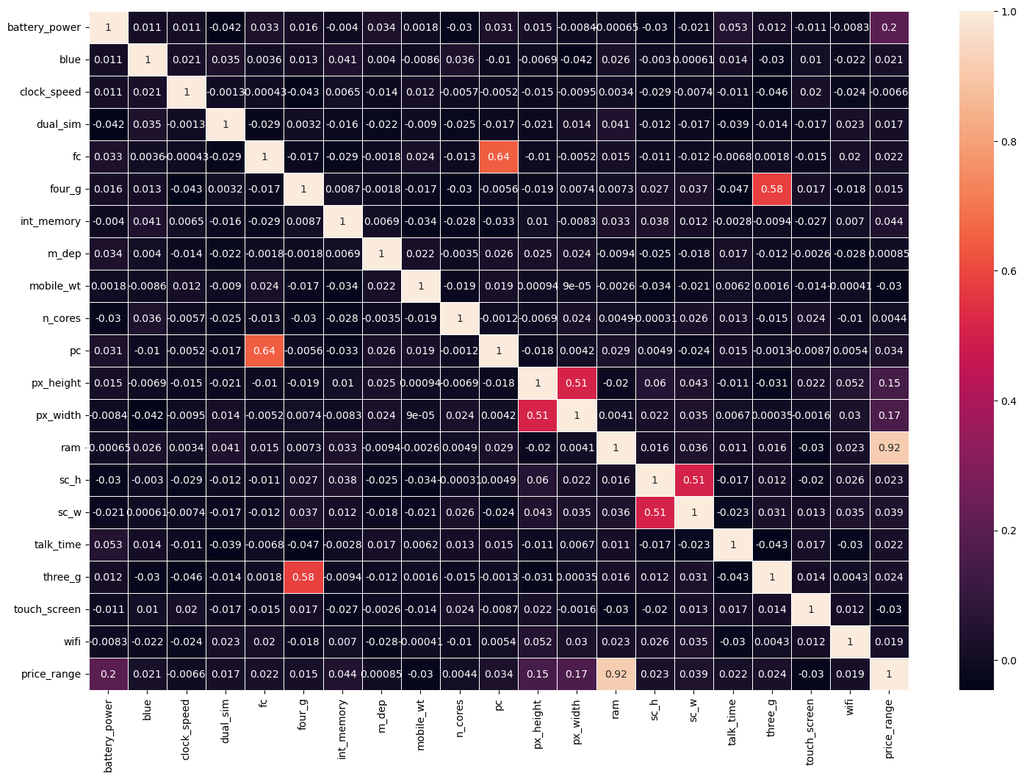

```python
import seaborn as sns
plt.figure(figsize=(18,12))
sns.heatmap(data=df.corr(), linecolor='white', linewidths=0.5, annot=True)
```

**Q3.2** List columns that correlate the most with the 'price_range' column.

**Note:** For this dataset any column that has correlation factor over or near 0.1 can be considered as a good predictor/ feature.

**A3.2** ram, px_width, px_height, battery_power

**Q3.3** Update the 'x' dataframe defined earlier in Q1 with your selected features/columns for 'price_range'.

**A3.3** Replace ??? with code in the code cell below

```python
# A3 Part 3:

x = df[['ram', 'px_width', 'px_height', 'battery_power']]
x.head(10)
```

|  | ram | px_width | px_height | battery_power |
| --- | --- | --- | --- | --- |
| 0 | 2549 | 756 | 20 | 842 |
| 1 | 2631 | 1988 | 905 | 1021 |
| 2 | 2603 | 1716 | 1263 | 563 |
| 3 | 2769 | 1786 | 1216 | 615 |
| 4 | 1411 | 1212 | 1208 | 1821 |
| 5 | 1067 | 1654 | 1004 | 1859 |
| 6 | 3220 | 1018 | 381 | 1821 |
| 7 | 700 | 1149 | 512 | 1954 |
| 8 | 1099 | 836 | 386 | 1445 |
| 9 | 513 | 1224 | 1137 | 509 |

**Q4:** Use seaborn *histplot* to plot a distribution graph for the price_range column

**A4** Replace ??? with code in the code cell below

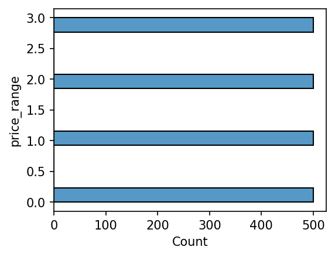

```python
plt.figure(figsize=(4,3),dpi=150)
#sns.?
sns.histplot(data=x, y=y)
```

**Q5:** Use seaborn *histplot* to present the relation between _price*range* and the *ram* of a mobile

**A5** Replace ??? with code in the code cell below

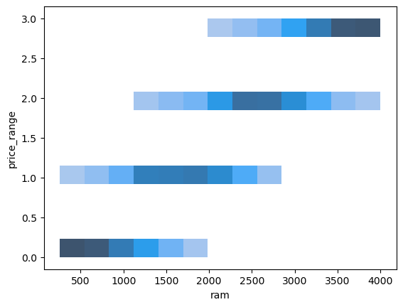

```python
#sns.?
sns.histplot(x=x['ram'], y=y)
```

**Q6:**

1. Use StandardScaler from sklearn to transform the x dataframe.
2. Split dataset into train and test data use train_test_split with test_size = 0.2 and random_state = 42
3. Check the number of instance in the train and test set.
4. Check the number of instance per class in train and test set using ytrain and ytest

**A6** Replace ??? with code in the code cell below

```python
#scaler = ?
#scaler.?
#x= scaler.?

scaler = StandardScaler()
scaler.fit(x)
x = scaler.transform(x)
#print(x)
```

```python
xtrain, xtest, ytrain, ytest = train_test_split(x, y, random_state=42, test_size=0.2)
```

```python
#print(?)
#print(?)
print(xtest)
print(ytest)
```

```
[[-1.32620097  0.82502108 -0.97844827  0.92755239]
 [ 0.40461305 -0.61448923 -0.83419687 -0.12865337]
 [-0.74526712 -0.69317628 -0.79362616  1.669628  ]
 ...
 [-0.30449509  0.02657887  1.31830459 -0.44278354]
 [-0.07857637  0.64218939 -0.26846088 -1.16209609]
 [ 0.29764745  0.90370814  0.43251079 -0.12182446]]
1860    0
353     2
1333    1
905     3
1289    1
       ..
965     3
1284    2
1739    1
261     1
535     2
Name: price_range, Length: 400, dtype: int64
```

```python
#ytrain.?
ytrain.shape
```

```
(1600,)
```

```python
#ytest.?
ytest.shape
```

```
(400,)
```

# Classification Model 1: Logistic Regression

Here, we fit Logistic Regression model to the train dataset using K-fold cross validation

**Q7** Train Logistic Regression Model

1. Create a logistic regression model using sklearn [linear_model](https://scikit-learn.org/stable/modules/generated/sklearn.linear_model.LogisticRegression.html) library.
2. Fit the model with the train data
3. Get the score from the model using test data
4. Plot confusion matrix using [ConfusionMatrixDisplay](https://scikit-learn.org/stable/modules/generated/sklearn.metrics.ConfusionMatrixDisplay.html), see [Visualization with Display Objects](https://scikit-learn.org/stable/auto_examples/miscellaneous/plot_display_object_visualization.html) example.

**A7** Replace ??? with code in the code cell below

```python
from sklearn.metrics import ConfusionMatrixDisplay, confusion_matrix
import matplotlib.pyplot as plt

# Create a logistic regression model using sklearn library
#clf=?
#clf.?
clf = LogisticRegression()
clf.fit(xtrain, ytrain)

#print score for test data
#print(?)
print(clf.score(xtest, ytest))
```

```
0.9725
```

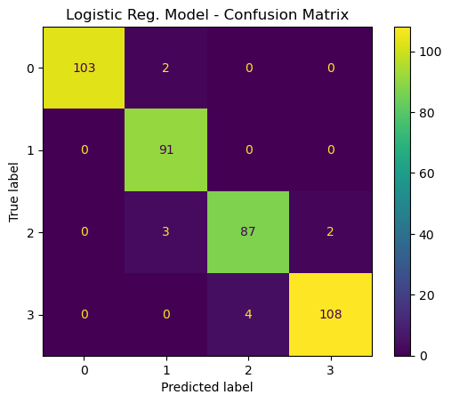

```python
#cm = ?
#plt.title("Logistic Reg. Model - Confusion Matrix")
#plt.xticks(?, ?, fontsize=11)
#plt.yticks(?, ?, fontsize=11)
#plt.show()

cm = confusion_matrix(ytest, clf.predict(xtest), labels=clf.classes_)
cm_display = ConfusionMatrixDisplay(cm).plot()
cm_display.ax_.set_title("Logistic Reg. Model - Confusion Matrix")
```

**Q8:** Train Logistic Regression Model using cross-validation on *xtrain, ytrain* data.

- Apply K fold cross validation technique for the model training (cross_val_score), and set K to 5 or 10.
- Print the different scores from different folds

**A8:** Replace ??? with code in the code cell below

```python
from sklearn.model_selection import cross_val_score

# Use sklearn for 5 fold cross validation
#scores_log= ?
scores_log_5 = cross_val_score(clf, xtrain, ytrain, cv=5)
scores_log_10 = cross_val_score(clf, xtrain, ytrain, cv=10)

# print the scores from different folds
#print(?)
print(scores_log_5)
print(scores_log_10)
```

```
[0.95625  0.953125 0.959375 0.95625  0.953125]
[0.93125 0.96875 0.96875 0.95    0.95    0.98125 0.975   0.93125 0.9375
 0.95625]
```

# Classification Model 2: K Nearest Neighbor Classifier

Here, we learn how to fit KNN on the train dataset using k-fold cross validation, and evaluate its classification accuracy on the train dataset using confusion matrix.

**Q9** Build a KNN Classification Model for the dataset as following:

1. Create a KNN model using sklearn library, and initialize n_neighbors as described in [documentation](https://scikit-learn.org/stable/modules/generated/sklearn.neighbors.KNeighborsClassifier.html).
2. Fit the model with the train data
3. Predict the values from test data
4. Print out the score from training and test data
5. Repeat Step 1.- 4. for a range of `n_neighbors` values (k in kNN) from 1 to 30.

**A9** Replace ??? with code in the code cell below

```python
from sklearn.neighbors import KNeighborsClassifier


# Define KNN model
#for k in range(?,?):

#    knn = ?

    #Fit KNN model on xtrain, ytrain from above
#    knn.?
    #predict y values from xtest
#    y_pred=knn.?

    #print score for test data
#    print("K: ",k,"Train Score: ",knn.?, "Test Score: ",knn.?)

for k in range(1, 31): # this does 1 through 30 inclusive
    knn = KNeighborsClassifier(n_neighbors=k)
    knn.fit(xtrain, ytrain)
    y_pred = knn.predict(xtest)
    print(f'K: {k}  Train Score: {knn.score(xtrain, ytrain)}  Test Score: {knn.score(xtest, ytest)}')
```

```
K: 1  Train Score: 1.0  Test Score: 0.8875
K: 2  Train Score: 0.933125  Test Score: 0.8675
K: 3  Train Score: 0.955  Test Score: 0.915
K: 4  Train Score: 0.92625  Test Score: 0.895
K: 5  Train Score: 0.930625  Test Score: 0.915
K: 6  Train Score: 0.92  Test Score: 0.91
K: 7  Train Score: 0.924375  Test Score: 0.91
K: 8  Train Score: 0.91875  Test Score: 0.9175
K: 9  Train Score: 0.92625  Test Score: 0.9225
K: 10  Train Score: 0.91875  Test Score: 0.9175
K: 11  Train Score: 0.9225  Test Score: 0.925
K: 12  Train Score: 0.92  Test Score: 0.9225
K: 13  Train Score: 0.924375  Test Score: 0.93
K: 14  Train Score: 0.92  Test Score: 0.91
K: 15  Train Score: 0.923125  Test Score: 0.915
K: 16  Train Score: 0.921875  Test Score: 0.915
K: 17  Train Score: 0.9225  Test Score: 0.915
K: 18  Train Score: 0.92  Test Score: 0.9025
K: 19  Train Score: 0.919375  Test Score: 0.9125
K: 20  Train Score: 0.9175  Test Score: 0.905
K: 21  Train Score: 0.91875  Test Score: 0.9
K: 22  Train Score: 0.92  Test Score: 0.9075
K: 23  Train Score: 0.916875  Test Score: 0.915
K: 24  Train Score: 0.92  Test Score: 0.9
K: 25  Train Score: 0.920625  Test Score: 0.9125
K: 26  Train Score: 0.92375  Test Score: 0.9125
K: 27  Train Score: 0.921875  Test Score: 0.915
K: 28  Train Score: 0.920625  Test Score: 0.9125
K: 29  Train Score: 0.91875  Test Score: 0.92
K: 30  Train Score: 0.913125  Test Score: 0.91
```

**Q9 Part 2:**

What is the best `n_neighbors`? Why?

**A9** Write your part 2 answer in this cell

- There are likely many "best" options. Anything between k=5 and k=19 is likely a good contender. In this range, the training and test scores are reasonably close, not showing signs of overfitting or underfitting. I will pick 9.

**Q10.**

1. Create a KNN Classifier model using the best value of k found from previous question.
2. Train the model using xtrain, ytrain values.
3. Plot confusion matrix for the xtest and ytest, using [ConfusionMatrixDisplay](https://scikit-learn.org/stable/modules/generated/sklearn.metrics.ConfusionMatrixDisplay.html), see [Visualization with Display Objects](https://scikit-learn.org/stable/auto_examples/miscellaneous/plot_display_object_visualization.html) example.

**A10** Replace ??? with code in the code cell below

```python
knn_best = KNeighborsClassifier(n_neighbors=9)

knn_best.fit(xtrain, ytrain)
```

```
KNeighborsClassifier(n_neighbors=9)
```

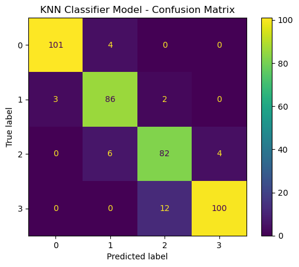

```python
#cm = ?
#plt.figure()
#plot_confusion_matrix(cm, figsize=(12,8), hide_ticks=True, cmap=plt.cm.Blues)
#plt.title("KNN Classifier Model - Confusion Matrix")
#plt.xticks(?)
#plt.yticks(?)
#plt.show()

#cm = confusion_matrix(ytest, clf.predict(xtest), labels=clf.classes_)

cm = confusion_matrix(ytest, knn_best.predict(xtest), labels=knn_best.classes_)
cm_display = ConfusionMatrixDisplay(cm).plot()
cm_display.ax_.set_title("KNN Classifier Model - Confusion Matrix")
```

**Q11** Train KNN classifier using cross-validation approach, [sklearn.cross_validation](https://scikit-learn.org/stable/modules/cross_validation.html) tutorial.

**Note:**

Try a range of `n_neighbors` values (k in kNN) from 1 to 30.

**A11** Replace ??? with code in the code cell below **

```python
# Define KNN model
from sklearn.model_selection import cross_val_score

for k in range(1 , 31): # for 1-30 inclusive
    #Define KNN model
    #knn_crossval = ?
    knn_crossval = KNeighborsClassifier(n_neighbors=k)
    # Use sklearn for 5 fold cross validation
    #scores_cv=?
    scores_cv = cross_val_score(knn_crossval, xtrain, ytrain, cv=5)
    # print the scores from different folds
    #print(?)
    print(scores_cv)
```

```
[0.834375 0.8375   0.865625 0.859375 0.865625]
[0.85    0.85    0.84375 0.84375 0.85   ]
[0.88125  0.878125 0.85     0.846875 0.85625 ]
[0.875    0.865625 0.846875 0.853125 0.85    ]
[0.8625   0.890625 0.8625   0.86875  0.85625 ]
[0.86875  0.890625 0.865625 0.878125 0.85    ]
[0.88125  0.8875   0.865625 0.865625 0.865625]
[0.8875   0.871875 0.88125  0.865625 0.859375]
[0.875    0.88125  0.890625 0.8625   0.878125]
[0.86875  0.890625 0.896875 0.871875 0.86875 ]
[0.859375 0.909375 0.903125 0.884375 0.86875 ]
[0.8625   0.8875   0.9125   0.878125 0.86875 ]
[0.875    0.890625 0.915625 0.875    0.88125 ]
[0.859375 0.903125 0.915625 0.8625   0.86875 ]
[0.875    0.903125 0.921875 0.871875 0.86875 ]
[0.875    0.9      0.909375 0.8625   0.871875]
[0.8875   0.915625 0.909375 0.878125 0.871875]
[0.8875   0.909375 0.896875 0.871875 0.88125 ]
[0.8875   0.915625 0.890625 0.875    0.884375]
[0.890625 0.90625  0.890625 0.875    0.86875 ]
[0.884375 0.925    0.89375  0.88125  0.8875  ]
[0.89375  0.915625 0.8875   0.878125 0.865625]
[0.88125  0.91875  0.890625 0.9      0.865625]
[0.896875 0.90625  0.884375 0.890625 0.8625  ]
[0.8875   0.915625 0.89375  0.90625  0.8625  ]
[0.884375 0.903125 0.884375 0.89375  0.875   ]
[0.890625 0.91875  0.90625  0.9      0.878125]
[0.884375 0.909375 0.890625 0.8875   0.88125 ]
[0.884375 0.909375 0.9      0.890625 0.890625]
[0.890625 0.90625  0.884375 0.884375 0.88125 ]
```

# Comparison

**Q12** Compare the two models (trained using xtrain,ytrain) in terms of score.

- Train two different models on Train data
- Predict xtest using the trained models
- Make a correlation matrix between ytest and predicted ytest values from the two Models
- Your resulting matrix should be `3x3 correlation matrix` for xtest, ytest data
  - The matrix is symmetric
  - It will provide the correlation between two models predictions plus ytest
  - Hint: You can create a new dataframe using these values and use corr() function for creating the corelation matrix. Use meaningful column name while creating the dataframe.

**A12** Replace ??? with code in the code cell below

```
(400,) (400,) (400,)
```

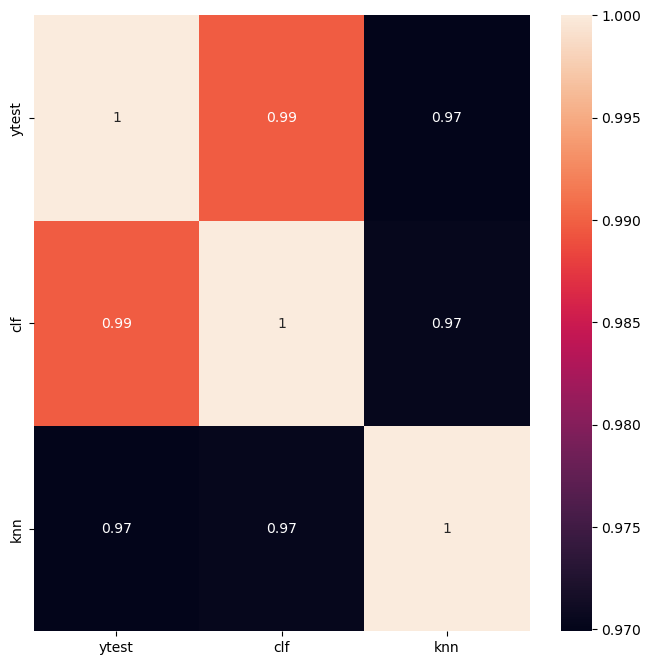

```python
import matplotlib.pyplot as plt
import seaborn as sns

# Predict Train dataset using logistic reg
#clf= LogisticRegression()
#clf.?
#ypred_clf=?

# Predict Train dataset using KNN
#knn= KNeighborsClassifier(n_neighbors=29)
#knn.?
#ypred_knn=?

#print(ytest.shape, ypred_clf.shape, ypred_knn.shape)
# Create a dataframe using the predicted results from the models
#df = ?

#copute correlation

# Now use seaborn library to plot the heatmap correlation matrix
#plt.figure(figsize=(8,8))
#sns.?

clf = LogisticRegression()
clf.fit(xtrain, ytrain)
ypred_clf = clf.predict(xtest)

knn = KNeighborsClassifier(n_neighbors=29)
knn.fit(xtrain, ytrain)
ypred_knn = knn.predict(xtest)

print(ytest.shape, ypred_clf.shape, ypred_knn.shape)

df_clf_knn = pd.DataFrame({'ytest': ytest, 'clf': ypred_clf, 'knn': ypred_knn})
plt.figure(figsize=(8,8))
sns.heatmap(data=df_clf_knn.corr(), annot=True)
```